# SUR Lecture

When Can Separate Equations Help Estimate Each Other?

| **Lecture label** | SUR lecture |
| --- | --- |
| **Main reading** | Chapter 11, Sections 11.2–11.2.5a |
| **Supporting reading** | “Baby Judge,” Sections 17.1–17.2.2 |
| **Anchor application** | General Electric and Westinghouse investment |

Anchor question

Should the investment equations for General Electric and Westinghouse be estimated separately, or can joint estimation give us meaningfully better evidence about the determinants of investment?

## Learning outcomes

After this lecture, you should be able to:

1. **Construct and interpret** the stacked representation of a system of regression equations, including its block-diagonal regressor matrix and disturbance covariance matrix.
2. **Compare** equation-by-equation OLS and feasible SUR, and predict when their coefficient estimates will be identical or different.
3. **Justify** whether SUR is useful in an applied problem using residual correlation, differences in regressors, sample size, and changes in estimated precision.

### Preparation and reference material

Read before class:

- “Baby Judge,” Sections 17.1–17.2.2, for the economic motivation and the move from two firm equations to one system.
- Main text, Section 11.2 through 11.2.1, for definitions, assumptions, and notation.

Useful reference material:

- Section 11.2.3: estimating the unknown contemporaneous covariance matrix;
- Section 11.2.5a: the Breusch–Pagan LM test;
- Section 11.2.5b: restrictions connecting coefficients across equations;
- Section 11.2.8: extensions allowing richer error processes.

You do not need to memorise

You do not need to memorise the expanded block-matrix estimator, the rules of Kronecker-product algebra, or the restricted-SUR formula. You should be able to explain the structure of the system, how feasible SUR is constructed, and the two circumstances in which SUR cannot improve on OLS.

## Lecture map

| Segment | Central move |
| --- | --- |
| Retrieval and connection | From single-equation GLS to system GLS |
| Hook | Should the two firms be estimated jointly? |
| Minimal theory | Stack, model covariance, apply GLS |
| Econometric lab | Diagnose, fail deliberately, estimate, stress-test |
| AI audit | Evaluate an apparently competent recommendation |
| Exit problem | Transfer the identical-regressor result |

# 1. Retrieval and connection

Suppose a linear model satisfies

$$E(\mathbf e\mid\mathbf X)=\mathbf0,
\qquad
\operatorname{Var}(\mathbf e\mid\mathbf X)=\boldsymbol\Omega
\neq\sigma^2\mathbf I.$$

Which statement is generally correct?

1. OLS is biased.
2. OLS remains unbiased, but may not be efficient.
3. GLS and OLS must produce identical estimates.
4. GLS can change standard errors but not coefficient estimates.

**Expected answer and connection**

**Answer: 2.** Under exogeneity, OLS remains unbiased. A non-spherical covariance matrix means that OLS need not be the best linear unbiased estimator. GLS can change both point estimates and their estimated standard errors.

SUR applies this familiar GLS principle to a new covariance structure: correlation between the disturbances of different equations in the same period.

# 2. The hook: two firms, two investment equations

For General Electric,

$$i_{1t}=\beta_{10}+\beta_{11}v_{1t}+\beta_{12}k_{1t}+e_{1t}.$$

For Westinghouse,

$$i_{2t}=\beta_{20}+\beta_{21}v_{2t}+\beta_{22}k_{2t}+e_{2t}.$$

Here (i) is investment, (v) is the firm’s market value—a proxy for expected profitability—and (k) is the existing capital stock.

**Record your prediction before seeing any estimates.**

1. Should ($e_{1t}$) and ($e_{2t}$) be positively or negatively correlated?
2. Will joint estimation change the coefficients, the standard errors, or both?
3. Which of the four slope estimates is most likely to change?
4. Is correlation between the two firms’ investment sufficient to justify SUR?

# 3. Minimal theory

## 3.1 From two equations to one “supermodel”

Write the two equations in the usual matrix form:

$$\mathbf i_1=\mathbf X_1\boldsymbol\beta_1+\mathbf e_1,
\qquad
\mathbf i_2=\mathbf X_2\boldsymbol\beta_2+\mathbf e_2.$$

Stacking gives

$$\underbrace{
\begin{bmatrix}
\mathbf i_1\\
\mathbf i_2
\end{bmatrix}}_{\mathbf i}
=
\underbrace{
\begin{bmatrix}
\mathbf X_1&\mathbf0\\
\mathbf0&\mathbf X_2
\end{bmatrix}}_{\mathbf X}
\underbrace{
\begin{bmatrix}
\boldsymbol\beta_1\\
\boldsymbol\beta_2
\end{bmatrix}}_{\boldsymbol\beta}
+
\underbrace{
\begin{bmatrix}
\mathbf e_1\\
\mathbf e_2
\end{bmatrix}}_{\mathbf e}.$$

For this application, (T=20) and each equation contains an intercept and two slopes:

| **Outcome** | **Regressors** | **Coefficients** | **Disturbances** |
| --- | --- | --- | --- |
| $\mathbf{i}: 40 \times 1$ | $\mathbf{X}: 40 \times 6$ | $\boldsymbol{\beta}: 6 \times 1$ | $\mathbf{e}: 40 \times 1$ |

Because the system regressor matrix is block diagonal,

$$\mathbf X'\mathbf X=
\begin{bmatrix}
\mathbf X_1'\mathbf X_1&\mathbf0\\
\mathbf0&\mathbf X_2'\mathbf X_2
\end{bmatrix}.$$

Consequently, OLS applied to the stacked system is exactly the same as OLS applied separately to each equation. Stacking is notation; it is not yet a new estimator.

## 3.2 What makes the equations statistically related?

Assume constant variances within each equation:

$$\operatorname{Var}(e_{1t})=\sigma_{11},
\qquad
\operatorname{Var}(e_{2t})=\sigma_{22},$$

and contemporaneous covariance

$$\operatorname{Cov}(e_{1t},e_{2t})=\sigma_{12}.$$

Errors belonging to different periods remain uncorrelated:

$$\operatorname{Cov}(e_{it},e_{js})=0
\quad\text{when }t\neq s.$$

The covariance matrix of the stacked disturbance is

$$\boldsymbol\Omega
=\operatorname{Var}(\mathbf e)
=
\begin{bmatrix}
\sigma_{11}\mathbf I_T&\sigma_{12}\mathbf I_T\\
\sigma_{12}\mathbf I_T&\sigma_{22}\mathbf I_T
\end{bmatrix}
=\boldsymbol\Sigma\otimes\mathbf I_T,$$

where

$$\boldsymbol\Sigma=
\begin{bmatrix}
\sigma_{11}&\sigma_{12}\\
\sigma_{12}&\sigma_{22}
\end{bmatrix}.$$

Contemporaneous correlation is not autocorrelation

- Contemporaneous correlation: $\operatorname{Cov}(e_{1t},e_{2t})\neq0$.
- Autocorrelation: $\operatorname{Cov}(e_{it},e_{i,t-1})\neq0$.

The basic SUR model allows the first and rules out the second.

Economically, a recession, credit-market disruption, or change in business expectations may affect both firms in the same period. If it is omitted from both equations, its influence appears in both errors. This does not mean that one firm’s investment causes the other firm’s investment.

## 3.3 GLS reveals how information crosses equations

If $\boldsymbol{\Omega}$ were known, the GLS estimator would be

$$\widehat{\boldsymbol\beta}_{GLS}
=
(\mathbf X'\boldsymbol\Omega^{-1}\mathbf X)^{-1}
\mathbf X'\boldsymbol\Omega^{-1}\mathbf i.$$

Let $\sigma^{ij}$ denote element $(i,j)$ of $\boldsymbol{\Sigma^{-1}}$. The GLS normal-equation matrix contains

$$\mathbf X'\boldsymbol\Omega^{-1}\mathbf X
=
\begin{bmatrix}
\sigma^{11}\mathbf X_1'\mathbf X_1 &
\sigma^{12}\mathbf X_1'\mathbf X_2\\
\sigma^{21}\mathbf X_2'\mathbf X_1 &
\sigma^{22}\mathbf X_2'\mathbf X_2
\end{bmatrix}.$$

The off-diagonal cross-products are the mathematical channel through which the equations can help estimate one another. They appear only because GLS uses the inverse covariance matrix.

## 3.4 Feasible SUR

The covariance matrix is unknown, so feasible SUR estimates it:

$$\boxed{
\text{separate OLS}
\longrightarrow
\widehat{\mathbf e}_1,\widehat{\mathbf e}_2
\longrightarrow
\widehat{\boldsymbol\Sigma}
\longrightarrow
\widehat{\boldsymbol\Omega}
\longrightarrow
\text{estimated GLS}
}$$

Using OLS residuals,

$$\widehat\sigma_{ij}
=\frac{\widehat{\mathbf e}_i'\widehat{\mathbf e}_j}{T},$$

or a common degrees-of-freedom correction, and

$$\widehat{\boldsymbol\beta}_{SUR}
=
[\mathbf X'(\widehat{\boldsymbol\Sigma}^{-1}\otimes\mathbf I_T)
\mathbf X]^{-1}
\mathbf X'(\widehat{\boldsymbol\Sigma}^{-1}\otimes\mathbf I_T)\mathbf i.$$

Two exact zero-gain cases

SUR and separate OLS give identical coefficient estimates when:

1. the cross-equation covariances are zero; or
2. every equation has the same explanatory-variable matrix.

High residual correlation is therefore not sufficient by itself.

## 3.5 Explore the efficiency result

For a simplified system with one standardized regressor in each equation, equal error variances, error correlation $\rho_e$, and regressor correlation $r_x$, the exact relative variance is

$$R(\rho_e,r_x)
=
\frac{\operatorname{Var}(\widehat\beta_{SUR})}
{\operatorname{Var}(\widehat\beta_{OLS})}
=\frac{1-\rho_e^2}{1-\rho_e^2r_x^2}.$$

Move both sliders. A ratio of one means no precision gain.

Error correlation, ρ<sub>e</sub>: 0.70 Regressor overlap, r<sub>x</sub>: 0.50

Relative variance: **0.58**  
SUR variance reduction: **42.0%**

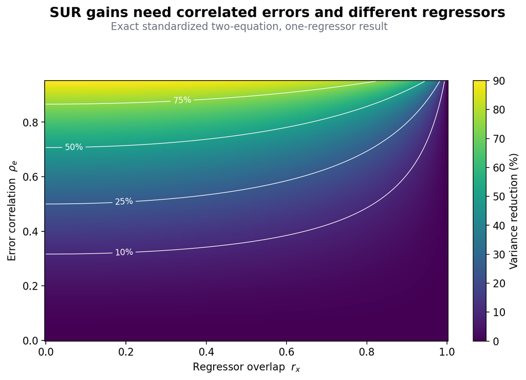

Exact efficiency map for the simplified system.

# 4. Econometric lab

The complete executable workflow is in `SUR-lecture.R`. The textbook’s 20 observations are entered directly in that script.

## Lab step 1 — Establish the separate-equation benchmark

**Question.** What do the two OLS equations say about the roles of market value and existing capital?

**Prediction.** Both slopes should be positive. Existing capital may be especially important for GE because it captures firm size and investment capacity.

**R action.**

```r
ge_ols <- lm(i1 ~ v1 + k1, data = investment)
west_ols <- lm(i2 ~ v2 + k2, data = investment)

broom::tidy(ge_ols, conf.int = TRUE)
broom::tidy(west_ols, conf.int = TRUE)
```

**Result.**

$$\widehat i_{1t}
=-9.956+0.0266v_{1t}+0.1517k_{1t},$$

$$\widehat i_{2t}
=-0.509+0.0529v_{2t}+0.0924k_{2t}.$$

Under separate OLS, GE capital and Westinghouse market value are precisely estimated. GE market value and Westinghouse capital are not statistically significant at the five-percent level.

**Interpretation.** Market value and capital are positively associated with investment, but their apparent relative importance differs between firms.

**Decision.** OLS supplies the benchmark. It has not used any possible connection between the firms’ unobserved shocks.

## Lab step 2 — Diagnose the relationship between the equations

**Question.** Do the equations contain related unexplained shocks?

**Prediction.** Common macroeconomic and credit-market shocks should create a positive residual correlation.

**R action.**

```r
residual_data <- investment |>
  transmute(
    year,
    ge_residual = residuals(ge_ols),
    west_residual = residuals(west_ols)
  )

rho_hat <- cor(
  residual_data$ge_residual,
  residual_data$west_residual
)

lm_statistic <- nrow(investment) * rho_hat^2
lm_p_value <- pchisq(lm_statistic, df = 1, lower.tail = FALSE)
```

**Result.**

$$\widehat\rho_{12}=0.729,
\qquad
\lambda=20(0.729)^2=10.63,
\qquad
p=0.0011.$$

For two equations, the Breusch–Pagan statistic has one degree of freedom under $H_0:\sigma_{12}=0$.

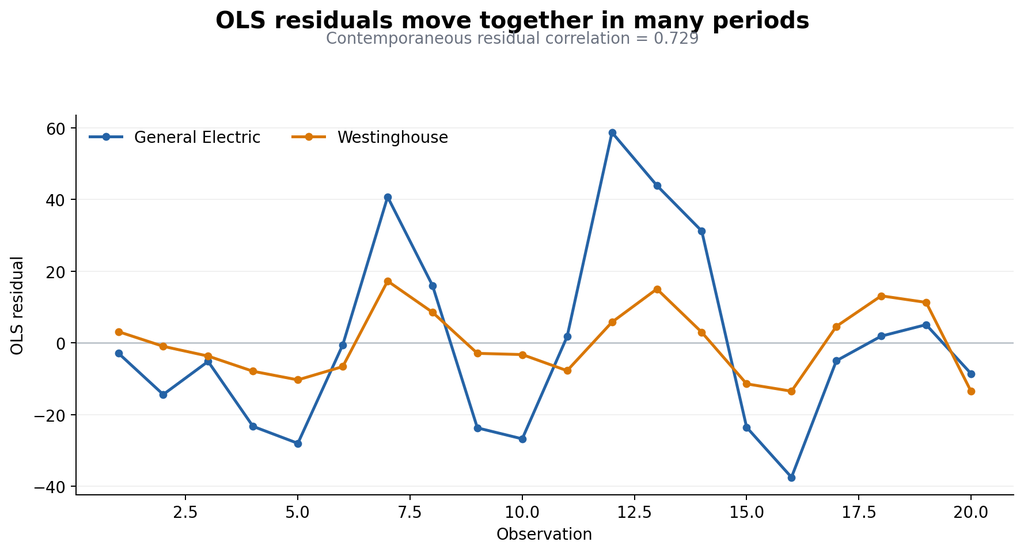

OLS residual series for General Electric and Westinghouse.

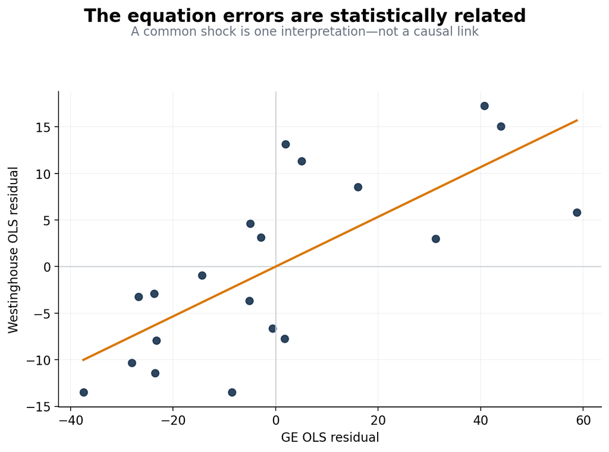

Scatterplot of the two equations’ OLS residuals.

**Interpretation.** Positive surprises in GE investment tend to occur in the same periods as positive surprises in Westinghouse investment, conditional on the included regressors.

**Decision.** There is evidence supporting a system estimator. The test does not tell us the size of the efficiency gain, establish causality, or diagnose autocorrelation.

## Lab step 3 — Deliberate failure: “system OLS”

**Question.** Does stacking both equations and applying OLS exploit the residual correlation?

**Prediction.** It is tempting to expect a new estimate because both equations now appear in one model.

**R action.**

```r
X1 <- model.matrix(ge_ols)
X2 <- model.matrix(west_ols)
T_obs <- nrow(investment)

X_system <- rbind(
  cbind(X1, matrix(0, T_obs, ncol(X2))),
  cbind(matrix(0, T_obs, ncol(X1)), X2)
)

y_system <- c(investment$i1, investment$i2)

beta_system_ols <- solve(
  crossprod(X_system),
  crossprod(X_system, y_system)
)
```

**Result.** System OLS reproduces the two separate OLS coefficient vectors, apart from machine rounding.

**Why the plausible approach fails.** The block-diagonal structure of $\mathbf{X}$ keeps the normal equations separated. OLS never uses $\hat{\sigma}_{12}$.

**Decision.** To transfer information across equations, the estimator must use $\widehat{\boldsymbol\Omega}^{-1}$.

## Lab step 4 — Estimate feasible SUR

**Question.** Does using the contemporaneous covariance change the economic evidence?

**Prediction.** Standard errors should generally fall, but the improvement need not be dramatic with only 20 observations.

**R action.**

```r
E_hat <- cbind(
  GE = residuals(ge_ols),
  Westinghouse = residuals(west_ols)
)

# Both equations contain three coefficients. Use the common divisor T - 3.
Sigma_hat <- crossprod(E_hat) / (T_obs - 3)
Omega_hat <- kronecker(Sigma_hat, diag(T_obs))
Omega_hat_inverse <- solve(Omega_hat)

sur_covariance <- solve(
  t(X_system) %*% Omega_hat_inverse %*% X_system
)

beta_sur <- sur_covariance %*%
  t(X_system) %*%
  Omega_hat_inverse %*%
  y_system

sur_standard_error <- sqrt(diag(sur_covariance))
```

**Result.**

| Equation | Variable | OLS estimate | OLS SE | SUR estimate | SUR SE |
| --- | --- | --- | --- | --- | --- |
| General Electric | Market value | 0.0266 | 0.0156 | 0.0383 | 0.0144 |
| General Electric | Capital | 0.1517 | 0.0257 | 0.1390 | 0.0250 |
| Westinghouse | Market value | 0.0529 | 0.0157 | 0.0576 | 0.0145 |
| Westinghouse | Capital | 0.0924 | 0.0561 | 0.0640 | 0.0530 |

The fitted SUR equations are

$$\widehat i_{1t}^{SUR}
=-27.719+0.0383v_{1t}+0.1390k_{1t},$$

$$\widehat i_{2t}^{SUR}
=-1.252+0.0576v_{2t}+0.0640k_{2t}.$$

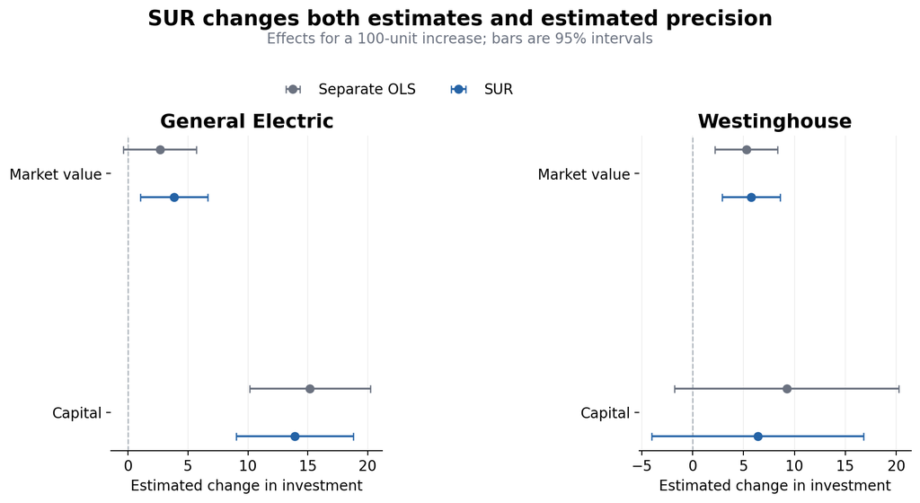

Comparison of OLS and SUR slope estimates.

**Interpretation.** SUR changes both estimates and estimated precision. The GE market-value coefficient becomes statistically distinguishable from zero at the five-percent level. The substantive conclusion for Westinghouse capital does not become stronger.

**Decision.** SUR is defensible because the residual correlation is large, the two equations do not have identical regressor matrices, and the changes matter for inference. The small sample means that feasible SUR’s finite-sample superiority should not be asserted as a theorem.

What SUR does not repair

If a common omitted macroeconomic shock is correlated with market value or capital, the exogeneity assumption can fail. SUR then combines biased equations efficiently; it does not remove the bias. SUR is also not an instrumental- variables estimator and does not solve simultaneity.

## Lab step 5 — Stress-test the efficiency claim

**Question.** Is a high residual correlation sufficient for SUR to change the estimates?

**Prediction.** A mechanically applied rule might say yes.

**R action.** For a mathematical demonstration—not an alternative economic specification—give both equations the same design matrix and compare separate OLS with SUR. The complete construction is in Lab Step 5 of `SUR-lecture.R`.

**Result.** With $\mathbf X_1=\mathbf X_2$, the maximum numerical difference between the SUR and OLS coefficients is below ($10^{-8}$).

**Interpretation.** The second equation helps estimate the first only when its regressor space supplies information that is not already represented in the first equation.

**Decision.** The applied question has three parts:

1. Are the contemporaneous disturbances correlated?
2. Do the equations contain sufficiently different regressors?
3. Is the resulting precision gain large enough to matter?

# 5. AI audit

Give an LLM the following exact prompt.

> We estimated annual investment equations for General Electric and Westinghouse using 20 observations:

> $$i_{1t}=\beta_{10}+\beta_{11}v_{1t}+\beta_{12}k_{1t}+e_{1t},$$

> $$i_{2t}=\beta_{20}+\beta_{21}v_{2t}+\beta_{22}k_{2t}+e_{2t}.$$

> The OLS residual correlation is 0.729. The Breusch–Pagan statistic for testing zero contemporaneous correlation is 10.63, with (p=0.0011).

> For the GE market-value coefficient, OLS gives 0.0266 with SE 0.0156, while SUR gives 0.0383 with SE 0.0144. For the Westinghouse market-value coefficient, OLS gives 0.0529 with SE 0.0157, while SUR gives 0.0576 with SE 0.0145.

> Write a recommendation of no more than 250 words on whether SUR should replace separate OLS. Explain: (1) what the residual correlation means; (2) why SUR changes the coefficient estimates; (3) whether the significant LM test guarantees that SUR is more efficient in this sample; (4) what happens if both equations have identical explanatory-variable matrices; (5) whether SUR solves omitted-variable bias or establishes causality; and (6) which assumptions must hold for the interpretation to be credible.

## Audit the answer

Do not grade the prose. Audit the econometrics:

- Does it distinguish disturbance correlation from outcome correlation?
- Does it distinguish contemporaneous correlation from autocorrelation?
- Does it recognize that stacked OLS equals separate OLS?
- Does it use both determinants of an efficiency gain?
- Does it distinguish asymptotic efficiency from finite-sample performance?
- Does it state a credible system-exogeneity condition?
- Does it recognize that SUR does not solve endogeneity?
- Does it avoid interpreting common residual shocks as a causal link?
- Does it take (T=20) seriously?
- Does its recommendation depend on more than the LM-test (p)-value?

### If the first answer is good

Use this follow-up:

> Design a Monte Carlo experiment with (T=20) that varies both the error correlation and the similarity of the equation regressors. Compare OLS and feasible SUR using bias and mean squared error. Before giving code, state the pattern you expect and explain why a significant residual-correlation test need not imply that feasible SUR has lower finite-sample mean squared error.

# 6. Exit problem

Two sectoral employment equations have residual correlation (0.85). Both equations contain exactly the same explanatory-variable matrix:

$$\mathbf X_1=\mathbf X_2.$$

Will SUR produce different coefficient estimates from separate OLS?

**Expected answer**

No. Even with high cross-equation error correlation,

$$\widehat{\boldsymbol\beta}_{SUR}
=\widehat{\boldsymbol\beta}_{OLS}$$

when the explanatory-variable matrices are identical.

Important wrong answers reveal different misconceptions:

- **“Yes, because 0.85 is high.”** Ignores the identical-regressor result.
- **“Only the standard errors will change.”** In the classical equal-(X) SUR system, the GLS covariance result also reduces to its equation-wise form.
- **“No, because correlated errors bias OLS.”** Gives the correct choice for the wrong reason. Under exogeneity, correlation across equations concerns efficiency rather than OLS bias.

# 7. Assessment connection

## New setting: crop acreage equations

A researcher estimates separate wheat and barley acreage equations using (T=40) annual observations. The equations contain different regressors. The OLS residual correlation is (0.55).

| Coefficient | OLS estimate | OLS SE | SUR estimate | SUR SE |
| --- | --- | --- | --- | --- |
| Wheat price in wheat equation | 0.42 | 0.18 | 0.47 | 0.13 |
| Barley price in barley equation | 0.31 | 0.16 | 0.28 | 0.12 |

## Part A — Closed-book individual reasoning

### A1. Interpret the residual correlation

What does the positive residual correlation of (0.55) mean?

**Solution**

Years with unexpectedly high wheat acreage also tend to have unexpectedly high barley acreage, conditional on the variables included in each equation. Common weather, policy, or input-cost shocks are possible explanations. It does not show that wheat acreage causes barley acreage.

### A2. Calculate the LM statistic

Test ($H_0:\sigma_{12}=0$).

**Solution**

$$\lambda=T\widehat\rho^2=40(0.55)^2=12.10.$$

There is one cross-equation covariance, so the reference distribution is $\chi^2(1)$. The null is rejected at conventional significance levels.

### A3. Compare the wheat-price evidence

How does the evidence concerning the wheat-price coefficient change?

**Solution**

Under OLS,

$$t=\frac{0.42}{0.18}=2.33.$$

Under SUR,

$$z\approx\frac{0.47}{0.13}=3.62.$$

The estimated association becomes somewhat larger and more precisely estimated. This strengthens evidence of a positive association, but does not by itself establish a causal response to price.

### A4. Change the regressor structure

Suppose both equations are respecified with identical explanatory-variable matrices. What happens to the coefficient estimates?

**Solution**

SUR and equation-by-equation OLS produce identical coefficient estimates, even if the residual correlation remains (0.55).

## Part B — Open-book / AI allowed

An analyst writes:

> The significant residual-correlation test proves that SUR is the best estimator. It also shows that common weather shocks cause both wheat and barley acreage to increase.

Critique the statement and recommend an estimation strategy. Explain:

- what the test establishes and what it does not;
- why the regressor matrices matter;
- what exogeneity assumptions are required;
- what diagnostic or sensitivity analysis you would perform;
- what additional evidence would support a causal interpretation.

### Grading rubric

| Level | Characteristics |
| --- | --- |
| **Insufficient** | Treats the LM test as proof of finite-sample superiority or causality; does not discuss regressors or exogeneity. |
| **Competent** | Explains contemporaneous correlation, compares OLS and SUR, and distinguishes efficiency from bias. |
| **Strong** | Also addresses finite-sample uncertainty, regressor overlap, system exogeneity, omitted weather variables, serial correlation, and a concrete robustness or simulation exercise. |

# 8. What comes next?

The next natural extension is to use the system structure for hypotheses that cannot be expressed within a single equation—for example,

$$H_0:\beta_{11}=\beta_{21}.$$

Such cross-equation restrictions are considered in Section 11.2.5b. The essential foundation is today’s result: once the equations are represented as one system, both covariance information and economic restrictions can connect their estimates.

# Instructor notes

**Open instructor-only guidance**

## Likely misconceptions

- Students may call contemporaneous correlation “autocorrelation.” Keep the indices (e_{1t},e_{2t}) visible when correcting this.
- Some will think SUR is a simultaneous-equations estimator. Ask whether any endogenous variable appears on the right-hand side.
- Some will describe SUR as pooling. Emphasize that each firm retains its own coefficient vector.
- A significant LM test is often treated as an automatic model-selection rule. Return to the efficiency widget and the small-sample qualification.
- Students may assume smaller standard errors mean omitted-variable bias has been repaired. Ask which assumption establishes unbiasedness or consistency.

## Places where discussion may expand

- The block-matrix normal equations can take longer than planned. The essential feature is the appearance of off-diagonal $\mathbf X_1'\mathbf X_2$ terms.
- The distinction between system exogeneity and residual correlation can lead naturally back to the earlier IV material.
- Students may ask why the SUR point estimates change. Use GLS as a weighted projection, rather than describing SUR as a standard-error correction.

## If time is short

- Show only the residual-series plot, not both residual plots.
- State rather than demonstrate the system-OLS equivalence numerically.
- Assign the identical-(X) calculation as the exit problem.
- Do not omit the AI audit’s causality and finite-sample questions.

## Questions if the room is quiet

- What omitted event could make both firms underinvest in the same year?
- If residual correlation were (0.95), would that alone settle the choice?
- Why does the second firm’s market value help estimate the first firm’s coefficient only through GLS?
- Which conclusion changes after SUR, and which remains unchanged?
- What variable would you add before making a causal claim?

## Likely AI-generated claims to challenge

- “SUR is unbiased because it corrects correlated errors.”
- “A significant Breusch–Pagan test proves that SUR is superior.”
- “SUR controls for common shocks.”
- “The smaller SUR standard errors establish causality.”
- “Since the equations are jointly estimated, their coefficients are pooled.”

## Single most important idea

**SUR gains precision by combining cross-equation error correlation with differences in the equations’ regressor spaces; neither ingredient is enough on its own.**